# Part 2：用 Skill 分析類別結果

Modeling Categorical Outcomes

**提示Goal**

結果變數是**類別**時，用**模型**同時描述多個解釋變數的效果。本頁先用課本例題快速介紹三個模型（兩類用**二元 logistic 迴歸**，三類以上沒有順序用 **baseline-category logit**，有順序用**累積 logit**；公式、檢定細節與 R code 都收在「點開查看」框裡），重點放在我為 Part 2 做的 **Skill**：它能做什麼、怎麼做出來、實測後怎麼改進，以及用真實資料實際操作的結果。

# 1 二元 logistic 迴歸（Logistic Regression）

## 1.1 資料與模型（Data and Model）

**資料**：$n$ 個觀察值 $(x_i, Y_i)$，$i = 1, \dots, n$，結果 $Y_i \in \{0, 1\}$（1 = 成功）。

**模型**：令 $\pi(x) = P(Y = 1 \mid x)$，

$$\text{logit}[\pi(x)] = \log\frac{\pi(x)}{1-\pi(x)} = \alpha + \beta x,
\qquad
\pi(x) = \frac{e^{\alpha+\beta x}}{1+e^{\alpha+\beta x}} .$$

**勝算比怎麼解釋？**

- **勝算比**：$x$ 增加 1 單位，勝算乘以 $e^{\beta}$：
  $$\frac{\text{odds}(x+1)}{\text{odds}(x)} = \frac{e^{\alpha+\beta(x+1)}}{e^{\alpha+\beta x}} = e^{\beta}.$$
- **機率尺度的變化**：曲線在 $x$ 的斜率是 $\beta\,\pi(x)[1-\pi(x)]$，在 $\pi(x) = 0.5$ 時最大，等於 $\beta/4$。
- **中位有效水準**（median effective level）：$\pi(x) = 0.5$ 發生在 $x = -\alpha/\beta$。

**警告注意**

$e^{\beta}$ 是**勝算**的倍數，不是**機率**的倍數；只有 $\pi$ 很小時兩者才接近。

**註釋細節：GLM、假設、估計、檢定統計量與決策規則（點開查看）**

logistic 迴歸是**廣義線性模型**（generalized linear model, GLM）的一種，由三個成分組成：

| 成分 | logistic 迴歸 |
| --- | --- |
| 隨機成分（random component） | $Y_i \sim \text{Bernoulli}(\pi_i)$，彼此獨立 |
| 系統成分（linear predictor） | $\eta_i = \alpha + \beta x_i$ |
| 連結函數（link function） | $\eta_i = \text{logit}(\pi_i)$ |

**註釋Note**

logit 把 $(0, 1)$ 的機率對應到整條實數線，所以不論 $x$ 多大多小，$\pi(x)$ 都落在 0 和 1 之間，畫出來是 S 形曲線。若改用一般線性迴歸 $\pi(x) = \alpha + \beta x$，預測機率可能超出 $[0, 1]$。

**假設（Assumption）**

1. 觀察值 $Y_1, \dots, Y_n$ 彼此**獨立**（同一個體有多筆資料時不成立，見 Part 3）。
2. 給定 $x_i$，$Y_i$ 服從 Bernoulli 分配，成功機率為 $\pi(x_i)$。
3. $\text{logit}[\pi(x)]$ 是 $x$ 的**線性**函數。
4. 推論採**大樣本**近似：樣本數相對於參數個數要夠大，且資料沒有**完全分離**（見下方「模型檢查」）。

**估計（Maximum Likelihood Estimation）**

概似函數與對數概似函數：

$$L(\alpha, \beta) = \prod_{i=1}^{n} \pi(x_i)^{y_i}\,[1-\pi(x_i)]^{1-y_i},
\qquad
\ell(\alpha, \beta) = \sum_{i=1}^{n}\Big[\, y_i(\alpha+\beta x_i) - \log\big(1+e^{\alpha+\beta x_i}\big) \Big].$$

令偏微分為 0，得到**概似方程式**（likelihood equations）：

$$\sum_{i=1}^{n}\big(y_i - \pi(x_i)\big) = 0, \qquad \sum_{i=1}^{n} x_i\big(y_i - \pi(x_i)\big) = 0 .$$

方程式沒有封閉解，以 **Newton–Raphson**（Fisher scoring，即 R 的 IRLS）迭代求解。估計量的變異數由**訊息矩陣**（information matrix）的反矩陣估計，$\widehat{\text{Var}}(\hat\beta)$ 開根號就是 $SE(\hat\beta)$。

**假設檢定（Hypothesis）**

檢定 $x$ 對 $Y$ 有沒有影響：

- 虛無假設：$H_0: \beta = 0$（$\pi(x)$ 不隨 $x$ 改變，$Y$ 和 $x$ 獨立）
- 對立假設（擇一）：右尾 $H_1: \beta > 0$、左尾 $H_2: \beta < 0$、雙尾 $H_3: \beta \neq 0$

**檢定統計量（Test Statistics）**

三種檢定都以 $\hat\beta$ 的大樣本常態性為基礎：

| 檢定 | 統計量 | $H_0$ 下的分配 |
| --- | --- | --- |
| Wald 檢定 | $z = \hat\beta / SE(\hat\beta)$，或 $z^2$ | $N(0,1)$；$z^2 \sim \chi^2_1$ |
| 概似比檢定（likelihood-ratio） | $LR = -2(\ell_0 - \ell_1) = D_0 - D_1$ | $\chi^2_1$ |
| Score 檢定 | 以 $H_0$ 下的斜率（score）標準化 | $\chi^2_1$ |

其中 $\ell_0$、$\ell_1$ 是虛無模型（只有截距）與完整模型的最大對數概似，$D_0$、$D_1$ 是兩個模型的 **deviance**。

**註釋Note**

大樣本時三者結果相近。樣本不大或效果很強時 Wald 檢定較不可靠，教科書建議優先使用**概似比檢定**與 **profile likelihood 信賴區間**（把 LR 檢定反轉得到的區間）。

**決策規則（Decision）**

顯著水準 $\alpha$ 下：

| 對立假設 | Wald 檢定：拒絕 $H_0$ 若 | 概似比檢定：拒絕 $H_0$ 若 |
| --- | --- | --- |
| 右尾 $H_1: \beta > 0$ | $z \geq z_\alpha$ | — |
| 左尾 $H_2: \beta < 0$ | $z \leq -z_\alpha$ | — |
| 雙尾 $H_3: \beta \neq 0$ | $\lvert z \rvert \geq z_{\alpha/2}$ | $LR \geq \chi^2_{1,\alpha}$ |

**信賴區間**：Wald 區間 $\hat\beta \pm z_{\alpha/2}\,SE(\hat\beta)$，取指數得勝算比區間 $\big(e^{\hat\beta - z_{\alpha/2}SE},\; e^{\hat\beta + z_{\alpha/2}SE}\big)$。勝算比區間**不包含 1** 等價於在雙尾檢定拒絕 $H_0$。

例題中勝算比的 95% Wald 區間為 $(1.35, 2.01)$，不包含 1。

## 1.2 課本例題（Worked Example）

馬蹄蟹（horseshoe crab）資料：173 隻雌蟹，$Y$ = 身邊是否有衛星雄蟹（1 有、0 沒有），$x$ = 背甲寬度（cm）。

**步驟 1：估計模型。** 以最大概似法得到

$$\text{logit}[\hat\pi(x)] = -12.351 + 0.497\,x, \qquad SE(\hat\beta) = 0.102 .$$

**步驟 2：解釋。**

- 勝算比：$e^{\hat\beta} = e^{0.497} = 1.644$，寬度每增加 1 cm，有衛星雄蟹的勝算乘以 1.64
- 預測機率：$\hat\pi(21) = 0.129$；平均寬度 $\bar x = 26.3$ 時 $\hat\pi = 0.674$；$\hat\pi(33.5) = 0.987$
- 平均寬度處的斜率：$\hat\beta\hat\pi(1-\hat\pi) = 0.497 \times 0.674 \times 0.326 = 0.109$，寬度每多 1 cm，機率約增加 0.109
- 中位有效水準：$-\hat\alpha/\hat\beta = 24.8$ cm

**步驟 3：檢定 $H_0: \beta = 0$。**

- Wald：$z = 0.497 / 0.102 = 4.89$，$z^2 = 23.9$
- 概似比：$LR = D_0 - D_1 = 225.8 - 194.5 = 31.3$，自由度 1

兩者都遠大於 $\chi^2_{1, 0.05} = 3.84$，拒絕 $H_0$：寬度和有沒有衛星雄蟹有關。

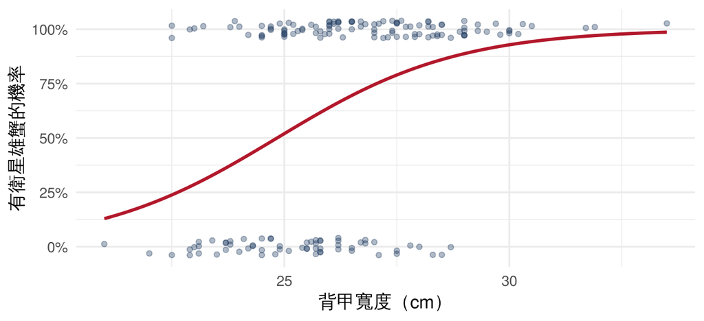

點：每隻雌蟹（上下稍微錯開）；曲線：模型預測的機率

**註釋R code — logistic 迴歸（點開查看）**

```r
Crabs <- read.table("data/agresti/Crabs.dat", header = TRUE)
fit <- glm(y ~ width, family = binomial, data = Crabs)
summary(fit)                          # 估計值、SE、Wald 檢定、deviance
```

```
Call:
glm(formula = y ~ width, family = binomial, data = Crabs)

Coefficients:
            Estimate Std. Error z value Pr(>|z|)
(Intercept) -12.3508     2.6287  -4.698 2.62e-06 ***
width         0.4972     0.1017   4.887 1.02e-06 ***
---
Signif. codes:  0 '***' 0.001 '**' 0.01 '*' 0.05 '.' 0.1 ' ' 1

(Dispersion parameter for binomial family taken to be 1)

    Null deviance: 225.76  on 172  degrees of freedom
Residual deviance: 194.45  on 171  degrees of freedom
AIC: 198.45

Number of Fisher Scoring iterations: 4
```

```r
exp(coef(fit))                        # 勝算比
```

```
 (Intercept)        width
4.326214e-06 1.644162e+00
```

```r
confint(fit)                          # profile likelihood 信賴區間（β）
```

```
                  2.5 %     97.5 %
(Intercept) -17.8100090 -7.4572470
width         0.3083806  0.7090167
```

```r
exp(confint(fit))                     # 勝算比的信賴區間
```

```
                   2.5 %       97.5 %
(Intercept) 1.841668e-08 0.0005772432
width       1.361219e+00 2.0319922986
```

```r
anova(fit, test = "LRT")              # 概似比檢定（D0 − D1）
```

```
Analysis of Deviance Table

Model: binomial, link: logit

Response: y

Terms added sequentially (first to last)

      Df Deviance Resid. Df Resid. Dev  Pr(>Chi)
NULL                    172     225.76
width  1   31.306       171     194.45 2.204e-08 ***
---
Signif. codes:  0 '***' 0.001 '**' 0.01 '*' 0.05 '.' 0.1 ' ' 1
```

```r
predict(fit, data.frame(width = c(21, 26.3, 33.5)), type = "response")   # 預測機率
```

```
        1         2         3
0.1290960 0.6740031 0.9866974
```

**註釋Note**

`summary()` 印出的 `z value` 與 `Pr(>|z|)` 是 **Wald 檢定**；`Null deviance` 減 `Residual deviance` 就是 **LR 統計量**。`confint()` 給的是 profile likelihood 區間，`confint.default()` 才是 Wald 區間 $\hat\beta \pm z_{\alpha/2} SE$。

## 1.3 多個解釋變數（Multiple Logistic Regression）

**模型**：

$$\text{logit}[\pi(\mathbf{x})] = \alpha + \beta_1 x_1 + \cdots + \beta_p x_p .$$

- $e^{\beta_j}$ 是**其他變數固定**時，$x_j$ 增加 1 的勝算比。
- 有 $c$ 類的**類別型解釋變數**用 $c-1$ 個指標變數（indicator variables）表示，係數是「該類 vs 參考類」的對數勝算比。
- **檢定一個變數的整體效果**：$H_0$：它的所有係數都是 0。用 LR 檢定比較有、沒有這個變數的兩個模型，自由度 = 少掉的參數個數；拒絕 $H_0$ 若 $LR \geq \chi^2_{df,\alpha}$。

**例題**：加入雌蟹顏色（1 淺 – 4 深，當類別變數）。

**註釋例題：加入顏色（點開查看）**

```r
fit2 <- glm(y ~ width + factor(color), family = binomial, data = Crabs)
summary(fit2)$coefficients
```

```
                   Estimate Std. Error     z value     Pr(>|z|)
(Intercept)    -11.38519276  2.8734572 -3.96219324 7.426439e-05
width            0.46795598  0.1055446  4.43372912 9.261698e-06
factor(color)2   0.07241694  0.7398922  0.09787498 9.220316e-01
factor(color)3  -0.22379766  0.7770789 -0.28799862 7.733478e-01
factor(color)4  -1.32991913  0.8525220 -1.55998209 1.187641e-01
```

```r
car::Anova(fit2)                      # 每個變數的 LR 檢定（Type II）
```

```
Analysis of Deviance Table (Type II tests)

Response: y
              LR Chisq Df Pr(>Chisq)
width          24.6038  1  7.041e-07 ***
factor(color)   6.9956  3    0.07204 .
---
Signif. codes:  0 '***' 0.001 '**' 0.01 '*' 0.05 '.' 0.1 ' ' 1
```

- 同樣顏色時，寬度每多 1 cm，勝算乘以 $e^{0.468} = 1.60$
- 顏色 4 相對顏色 1 的勝算比 $= 0.26$
- 顏色的整體 LR 檢定：$LR = 7.00$，$df = 3$，$P = 0.072$；$\chi^2_{3,0.05} = 7.81$，在 $\alpha = 0.05$ 下**不拒絕** $H_0$

**註釋Note**

有順序的類別（例如顏色 1–4）也可以當**數值分數**放入模型，只用 1 個參數，但假設每差一級效果相同。當類別變數則不做此假設、但多用參數。兩種做法可用 LR 檢定比較。

**註釋模型檢查：適合度、ROC、完全分離、樣本數（點開查看）**

**(1) 適合度（goodness of fit）**。解釋變數都是類別、資料可以分組時，用 deviance 或 Pearson 統計量

$$G^2 = 2\sum \text{observed} \log\frac{\text{observed}}{\text{fitted}}, \qquad X^2 = \sum \frac{(\text{observed}-\text{fitted})^2}{\text{fitted}}$$

與 $\chi^2_{df}$ 比較，$df$ = 組數 − 參數個數。有**連續**解釋變數時（如寬度），每組幾乎只有一個觀察值，$G^2$ 沒有卡方分配，**不能**當適合度檢定，應改和更複雜的模型（例如加入二次項或交互作用）做 LR 比較。

**(2) 預測能力：ROC 曲線**。以預測機率 $\hat\pi_i$ 對所有切點畫出敏感度對 1 − 特異度。**曲線下面積**（AUC）又稱 **concordance index**：隨機取一個 $y = 1$ 和一個 $y = 0$ 的觀察值，模型給前者較高預測機率的機率。0.5 = 亂猜，1 = 完美區分。

```r
library(pROC)
c(只用寬度 = auc(roc(Crabs$y, fitted(fit), quiet = TRUE)),
  寬度加顏色 = auc(roc(Crabs$y, fitted(fit2), quiet = TRUE)))
```

```
  只用寬度 寬度加顏色
 0.7424441  0.7713601
```

**(3) 完全分離（complete separation）**。若某個 $x$ 值以下全是 0、以上全是 1，概似函數沒有最大值，$\hat\beta = \infty$：

```r
toy <- data.frame(x = 1:6, y = c(0, 0, 0, 1, 1, 1))
summary(glm(y ~ x, family = binomial, data = toy))$coefficients
```

```
              Estimate Std. Error       z value  Pr(>|z|)
(Intercept) -165.31783   407521.4 -0.0004056666 0.9996763
x             47.23367   115264.4  0.0004097853 0.9996730
```

軟體印出的係數與 SE 都大得離譜，Wald 檢定沒有意義。此時應看 LR 檢定與 profile likelihood 區間（下限有限、上限無限大）。

**(4) 樣本數**。經驗法則：較少的那一類結果，每個參數至少約 **10 個**觀察值，否則估計可能有偏誤、SE 不準。

# 2 Baseline-Category Logit 模型（名目結果）

## 2.1 資料與模型（Data and Model）

**資料**：結果 $Y$ 有 $J$ 個**沒有順序**的類別，$\pi_j(x) = P(Y = j \mid x)$，$\sum_j \pi_j(x) = 1$。

**模型**：選第 $J$ 類為**基準類別**（baseline），其他每一類各和它配對成一條 logit：

$$\log\frac{\pi_j(x)}{\pi_J(x)} = \alpha_j + \beta_j x, \qquad j = 1, \dots, J-1 .$$

任兩類的比較可由方程式相減得到，例如 $\log(\pi_a/\pi_b) = (\alpha_a - \alpha_b) + (\beta_a - \beta_b)x$。各類機率：

$$\pi_j(x) = \frac{e^{\alpha_j+\beta_j x}}{1 + \sum_{h=1}^{J-1} e^{\alpha_h+\beta_h x}}, \qquad \pi_J(x) = \frac{1}{1 + \sum_{h=1}^{J-1} e^{\alpha_h+\beta_h x}} .$$

**註釋細節：假設、檢定統計量與決策規則（點開查看）**

**假設（Assumption）**

1. 觀察值彼此獨立；給定 $x$，$Y$ 服從多項分配（multinomial）。
2. 每條方程式的 logit 是 $x$ 的線性函數。
3. 結果類別**沒有順序**（有順序時改用第 3 節的模型，才能利用順序資訊）。

**註釋Note**

基準類別的選擇**不影響**模型的配適與預測機率，只改變係數是「和誰比」。

**假設檢定與統計量（Hypothesis and Test Statistic）**

- $H_0: \beta_1 = \beta_2 = \cdots = \beta_{J-1} = 0$（$x$ 對 $Y$ 的分布沒有影響）
- $H_1$：至少一個 $\beta_j \neq 0$

**LR 統計量**：$LR = -2(\ell_0 - \ell_1)$，$H_0$ 下近似 $\chi^2_{J-1}$（一個解釋變數在每條方程式各有一個係數）。個別係數 $\beta_j$ 可用 Wald $z = \hat\beta_j / SE(\hat\beta_j)$ 檢定。

**決策規則（Decision）**

| 檢定目標 | 統計量 | 拒絕 $H_0$ 若 |
| --- | --- | --- |
| $x$ 的整體效果 $H_0: \beta_1 = \cdots = \beta_{J-1} = 0$ | $LR$ | $LR \geq \chi^2_{J-1,\alpha}$ |
| 單一方程式 $H_0: \beta_j = 0$（雙尾） | Wald $z$ | $\lvert z \rvert \geq z_{\alpha/2}$ |

## 2.2 課本例題（Worked Example）

佛州 59 隻鱷魚的主食：魚（F）、無脊椎動物（I）、其他（O），$x$ = 體長（公尺）。以 O 為基準類別。

**步驟 1：估計。**

$$\log\frac{\hat\pi_F}{\hat\pi_O} = 1.618 - 0.110\,x,
\qquad
\log\frac{\hat\pi_I}{\hat\pi_O} = 5.697 - 2.465\,x .$$

**步驟 2：解釋。**

- 體長每多 1 公尺，「無脊椎 vs 其他」的勝算乘以 $e^{-2.465} = 0.085$：越大的鱷魚越少吃無脊椎動物
- 「魚 vs 無脊椎」由相減得到：$\hat\beta_F - \hat\beta_I = -0.110 - (-2.465) = 2.355$，勝算比 $10.54$

**步驟 3：檢定 $H_0: \beta_F = \beta_I = 0$。** $LR = 16.80$，$df = 2$，$\chi^2_{2,0.05} = 5.99$，拒絕 $H_0$：體長和主食有關（$P < 0.001$）。

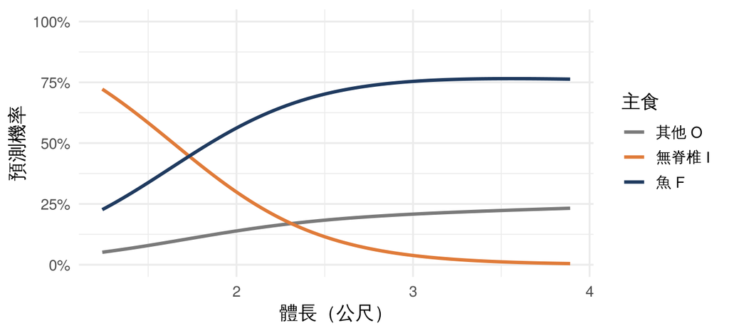

**註釋R code — baseline-category logit（點開查看）**

```r
library(VGAM)
Gators <- read.table("data/agresti/Alligators.dat", header = TRUE)
fit3 <- vglm(y ~ x, family = multinomial(refLevel = "O"), data = Gators)   # 基準類別 = O
coef(summary(fit3))                   # :1 = F vs O，:2 = I vs O
```

```
               Estimate Std. Error    z value    Pr(>|z|)
(Intercept):1  1.617731  1.3072716  1.2374869 0.215906362
(Intercept):2  5.697444  1.7937419  3.1762898 0.001491719
x:1           -0.110109  0.5170814 -0.2129433 0.831371158
x:2           -2.465446  0.8996026 -2.7405947 0.006132810
```

```r
fit3_0 <- vglm(y ~ 1, family = multinomial(refLevel = "O"), data = Gators)
deviance(fit3_0) - deviance(fit3)     # LR 統計量，df = 2
```

```
[1] 16.80061
```

# 3 累積 Logit 模型（有序結果）

## 3.1 資料與模型（Data and Model）

**資料**：結果 $Y$ 有 $J$ 個**有順序**的類別 $1 < 2 < \cdots < J$。

**累積機率**：$P(Y \leq j \mid x) = \pi_1(x) + \cdots + \pi_j(x)$，$j = 1, \dots, J-1$。

**模型**（比例勝算模型，proportional odds model）：

$$\text{logit}\,P(Y \leq j \mid x) = \alpha_j + \beta x, \qquad j = 1, \dots, J-1 .$$

每個切點有自己的截距 $\alpha_1 < \alpha_2 < \cdots < \alpha_{J-1}$，但**共用同一個斜率** $\beta$。

- $x$ 增加 1，任何切點的累積勝算 $\dfrac{P(Y\le j)}{P(Y>j)}$ 都乘以 $e^{\beta}$。
- 換成「落在**較高**類別」的方向，勝算乘以 $e^{-\beta}$。

**註釋Note**

有些軟體寫成 $\text{logit}\,P(Y \le j) = \alpha_j - \beta x$（例如 `MASS::polr`），此時 $\beta > 0$ 代表傾向較高類別。解釋係數前要先確認軟體的參數化；本頁用 `VGAM::vglm`，是 $\alpha_j + \beta x$。

**註釋細節：假設、檢定統計量與決策規則（點開查看）**

**假設（Assumption）**

1. 觀察值彼此獨立；給定 $x$，$Y$ 服從多項分配。
2. 結果類別有自然的順序。
3. **比例勝算假設**：$x$ 對每一個累積 logit 的效果 $\beta$ 都相同。

**假設檢定與統計量（Hypothesis and Test Statistic）**

- $H_0: \beta = 0$（$x$ 和 $Y$ 獨立）；$H_1: \beta \neq 0$
- **LR 統計量** $LR = -2(\ell_0 - \ell_1)$，$H_0$ 下近似 $\chi^2_1$（每個解釋變數只有一個參數，比 baseline-category logit 的 $J-1$ 個更精簡，檢定力也較高）。

**決策規則（Decision）**

| 對立假設 | 統計量 | 拒絕 $H_0$ 若 |
| --- | --- | --- |
| 雙尾 $H_1: \beta \neq 0$ | $LR$ | $LR \geq \chi^2_{1,\alpha}$ |
| 雙尾 $H_1: \beta \neq 0$ | Wald $z = \hat\beta/SE$ | $\lvert z \rvert \geq z_{\alpha/2}$ |
| 右尾（傾向較低類別）$H_1: \beta > 0$ | Wald $z$ | $z \geq z_\alpha$ |
| 左尾（傾向較高類別）$H_1: \beta < 0$ | Wald $z$ | $z \leq -z_\alpha$ |

## 3.2 課本例題（Worked Example）

美國民眾的政治意識形態：1 非常自由、2 有點自由、3 中間、4 有點保守、5 非常保守；解釋變數為政黨（民主黨、共和黨）與性別。

**步驟 1：估計。** $\hat\beta_{\text{共和黨}} = -3.634$，$\hat\beta_{\text{男性}} = 0.047$。

**步驟 2：解釋。** 控制性別後，共和黨落在**較保守**類別的勝算是民主黨的 $e^{3.634} = 37.9$ 倍，而且這個倍數對每一個切點都相同。

**步驟 3：檢定。**

- 政黨：$LR = 403.2$，$df = 1$，遠大於 $\chi^2_{1,0.05} = 3.84$，拒絕 $H_0$
- 性別：$LR = 0.10$，$P = 0.752$，不拒絕 $H_0$

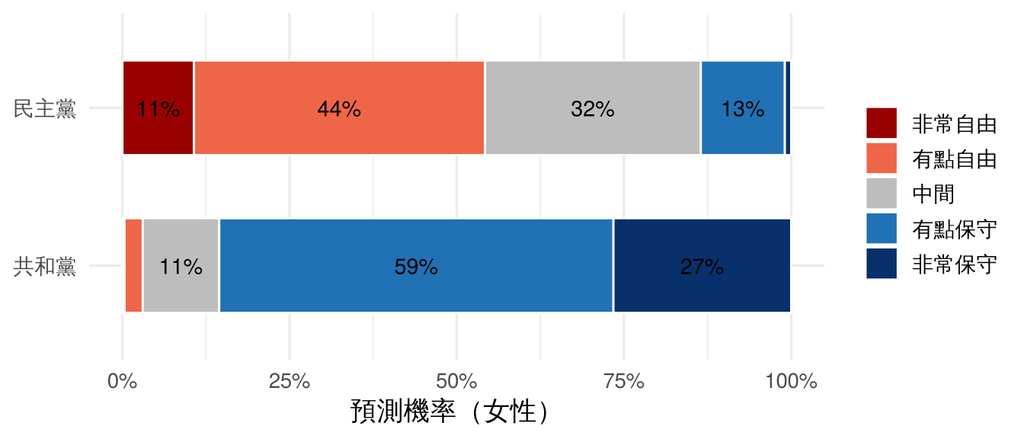

**註釋R code — 累積 logit（點開查看）**

```r
Pol <- read.table("data/agresti/Polviews.dat", header = TRUE)
Pol                                   # y1 非常自由 … y5 非常保守（彙整次數）
```

```
  gender party y1  y2 y3 y4 y5
1 female   dem 25 105 86 28  4
2 female repub  0   5 15 83 32
3   male   dem 20  73 43 20  3
4   male repub  0   1 14 72 32
```

```r
fit4 <- vglm(cbind(y1, y2, y3, y4, y5) ~ party + gender,
             family = cumulative(parallel = TRUE), data = Pol)   # parallel = TRUE：比例勝算
coef(summary(fit4))
```

```
                 Estimate Std. Error     z value     Pr(>|z|)
(Intercept):1 -2.12232620  0.1687523 -12.5765768 2.840752e-36
(Intercept):2  0.16891554  0.1148098   1.4712645 1.412196e-01
(Intercept):3  1.85715563  0.1510296  12.2966352 9.442641e-35
(Intercept):4  4.65005237  0.2349637  19.7905138 3.593600e-87
partyrepub    -3.63365808  0.2178476 -16.6798147 1.837880e-62
gendermale     0.04731236  0.1495510   0.3163628 7.517272e-01
```

```r
exp(-coef(fit4)[c("partyrepub", "gendermale")])                # 落在較高類別的勝算比
```

```
partyrepub gendermale
37.8510256  0.9537894
```

## 3.3 比例勝算假設的檢查（Checking Proportional Odds）

比較比例勝算模型（$\beta$ 共用）與每個切點各有 $\beta_j$ 的一般模型：

- $H_0$：比例勝算成立（$\beta_1 = \cdots = \beta_{J-1}$）
- $LR = -2(\ell_{\text{PO}} - \ell_{\text{general}})$，$df = (J-2) \times p$（$p$ = 解釋變數的參數個數）

**註釋R code — 比例勝算假設檢定（點開查看）**

```r
fit4_np <- vglm(cbind(y1, y2, y3, y4, y5) ~ party + gender,
                family = cumulative(parallel = FALSE), data = Pol)
LR_po <- deviance(fit4) - deviance(fit4_np)
df_po <- df.residual(fit4) - df.residual(fit4_np)
c(LR = LR_po, df = df_po, P = pchisq(LR_po, df_po, lower.tail = FALSE))
```

```
       LR        df         P
6.2210925 6.0000000 0.3988846
```

例題中 $LR = 6.22$，$df = 6$，$P = 0.399$，不拒絕 $H_0$，比例勝算模型適用。

**警告注意**

- 假設被拒絕時，單一勝算比可能過度簡化（例如某一組只是分布較分散，而不是整體往上移），應分開描述各切點的效果。
- **不要**把有序結果壓成兩類再做二元 logistic：會損失資訊，結論還會隨切點改變。

# 4 怎麼選模型？

| 結果變數 | 模型 | 一個解釋變數的參數個數 | 整體效果的 LR 檢定自由度 |
| --- | --- | --- | --- |
| 兩類 | 二元 logistic 迴歸 | 1 | 1 |
| $J$ 類，沒有順序 | baseline-category logit | $J-1$ | $J-1$ |
| $J$ 類，有順序 | 累積 logit（比例勝算） | 1 | 1 |
| 同一個體有多筆資料 | 以上模型都不適用 → Part 3 |  |  |

# 5 Skill 介紹：categorical-modeling

## 5.1 這個 Skill 做什麼？

**categorical-modeling** 是我為 Part 2 做的 Claude Skill，專門處理**結果變數是類別**的迴歸模型。使用者丟入資料檔，用平常說話的方式問「哪些因素會影響……？」，Skill 會：

[output not shown]

| 使用者的問題 | Skill 用的方法 | 指令 |
| --- | --- | --- |
| 結果兩類（及格／不及格） | 二元 logistic 迴歸 | `logistic` |
| 結果三類以上、沒有順序（選校原因） | baseline-category logit | `multinomial` |
| 結果三類以上、有順序（飲酒量 1–5） | 累積 logit（比例勝算模型） | `ordinal` |
| 「這個變數當數值還是類別好？」「這個變數要不要放？」 | 比較兩個模型（概似比檢定、AIC） | `compare` |
| 「幫我整理成報告」 | 把所有結果整理成一份 HTML 報告 | `report` |

範圍外的問題（同一個體有多筆資料、結果是計數或連續數值），Skill 會說明原因和適合的方法，**不會硬套**。

**重要行為規則（最優先）**

1. **未經使用者明確同意，不畫圖、不配適、不比較模型、不產生報告**
2. 資料是否獨立**一定讓使用者確認**（資料本身看不出來）
3. 每則訊息結尾都寫清楚「回覆什麼就會做什麼」
4. **所有數字都由程式計算**，Claude 不能心算、修改數字，也不能從圖上估讀

## 5.2 檔案結構（File Structure）

Skill 採用**分層設計**：主檔精簡、永遠載入；知識放在 `references/`，需要時才讀；計算交給 `scripts/`。

```
categorical-modeling/
├── SKILL.md                    <- 主檔：行為規則與分析流程（大腦）
├── references/
│   ├── methods.md              <- 速查：三個模型＋模型比較的 H0、統計量、效果量
│   ├── textbook-methods.md     <- 課本細節：假設、公式、注意事項
│   └── decision-tree.md        <- 選模型的決策樹、配適後建議的比較
├── scripts/
│   └── run_model.py            <- 實際計算（statsmodels）＋畫圖＋比較模型＋產生報告
├── data/                       <- 範例資料（馬蹄蟹、鱷魚、高中生）
├── decision-tree.png           <- 決策樹圖
├── README.md                   <- 安裝與使用說明
└── skill-overview.qmd          <- Skill 介紹頁
```

| 檔案 | 用途 |
| --- | --- |
| `SKILL.md` | 定義 Skill 什麼時候啟動、涵蓋範圍、行為規則、六步驟流程、怎麼解釋每個模型的結果 |
| `methods.md` | 一頁速查：模型式、$H_0$、統計量、勝算比怎麼解釋、對應的指令 |
| `textbook-methods.md` | 最深的一層：完整假設、估計與推論、模型檢查、模型比較、常見誤解，附 Agresti 節號 |
| `decision-tree.md` | 幫 Claude 決定用哪個模型、還要問使用者哪些設定、配適後建議做哪些比較 |
| `run_model.py` | 被執行的程式（Python）：描述資料、畫圖、配適與比較模型、產生報告 |

## 5.3 怎麼使用？

把 Skill 資料夾壓成 `categorical-modeling.zip`，上傳到 Claude App 就能在網頁版、桌面版使用：

1. **Settings → Capabilities**：開啟「程式碼執行與檔案建立」
2. **Customize → Skills**：按 **＋** → **Create skill** → **Upload a skill**，上傳 ZIP
3. 開一個新對話，上傳資料檔，用平常說話的方式提問

> 用 categorical-modeling skill 分析這份資料：哪些因素會影響學生是否及格？

## 5.4 Skill 怎麼選模型？

先確認資料**是否獨立**、結果變數**是什麼型態**，再依「幾類、有沒有順序」選模型，最後確認模型設定：

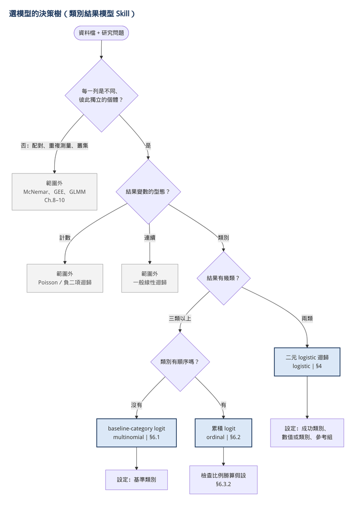

選模型的決策樹（decision-tree.png）

## 5.5 一則訊息確認所有設定

資料看不出來的事，Skill 不會自己猜，而是用**一則確認清單**一次列出所有設定，每項都附上建議的預設值和理由：

| 編號 | 要確認的事 | 為什麼要問 |
| --- | --- | --- |
| ① | 每一列是不是不同、獨立的個體？ | 資料本身證明不了獨立；不獨立就不能用這三個模型 |
| ② | 結果有幾類？有沒有順序？ | 決定用哪一個模型 |
| ③ | 數字代碼（例如 1–4）要當數值還是類別？ | 當數值只用 1 個參數、假設等距效果；當類別則每類各自估計 |
| ④ | 類別型解釋變數的參考組 | 決定勝算比是「和誰比」 |
| ⑤ | 「成功」是哪一類／基準類別 | 決定勝算比的方向；多類別模型的比較對象 |
| ⑥ | 樣本數夠不夠？ | Skill 自己檢查：較少的一類，每個參數約 10 個以上 |

④⑤ 的預設值是程式固定的：參考組是排序後的第一類，成功類別是 1／yes／pass 這類肯定的類別，基準類別是 other（沒有就用最後一類）。所以不同的人用同一份資料，基準都一樣，結果可以互相對照。

使用者只要回覆「**照預設**」就開始計算；要改設定，只寫編號和新設定，例如「③ failures 改當類別」。

**註釋實際畫面：Skill 的確認清單（點開查看）**

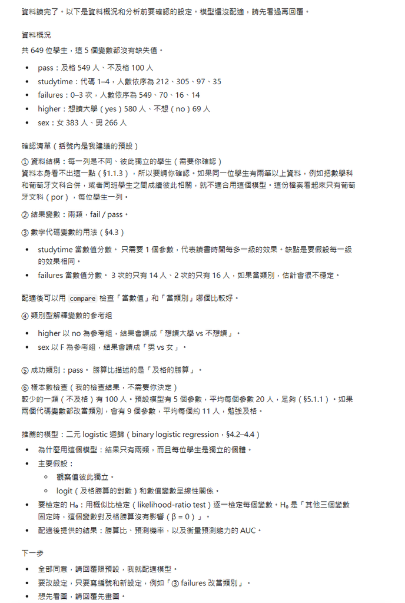

## 5.6 它會算出什麼、提醒什麼？

| 指令 | 輸出 | 圖 |
| --- | --- | --- |
| `logistic` | 勝算比與 profile 信賴區間、每個變數的概似比檢定、AUC、預測機率 | 預測機率曲線、ROC 曲線 |
| `multinomial` | 每條方程式的勝算比、每個變數的概似比檢定、各類別預測機率 | 各類別預測機率 |
| `ordinal` | 「落在較高類別」的勝算比、概似比檢定、**比例勝算假設檢定** | 各類別預測機率 |
| `compare` | 兩個模型的對數概似、AIC；巢狀時加上概似比檢定與結論 | — |
| `report` | 一份 HTML 報告：結論摘要、表格、圖、注意事項 | 放入所有圖 |

| 警告代碼 | Skill 的提醒 |
| --- | --- |
| `SEPARATION` | 完全分離：係數其實是無限大，不要看 Wald 檢定，改看概似比檢定 |
| `FEW_EVENTS` | 樣本相對參數太少，估計可能不穩定 |
| `GOF_NOTE` | 有數值解釋變數時，deviance 不能當適合度檢定；建議用 `compare` 和更複雜的模型比較 |
| `PO_VIOLATED` | 比例勝算假設不成立，一個勝算比可能過度簡化 |
| `NOT_NESTED` | 兩個模型不是巢狀，不能做概似比檢定，只能比較 AIC |
| `MISSING` | 排除了幾筆缺失資料，以及什麼情況下會造成偏誤 |

## 5.7 比較兩個模型：數值還是類別？

數字代碼（例如被當次數 0–3）可以當**數值分數**，也可以當**類別**：

|  | 當數值分數 | 當類別 |
| --- | --- | --- |
| 參數個數 | 1 個 | 類別數 − 1 個（0–3 是 3 個） |
| 假設 | 每增加一級，效果都相同（等距） | 不做等距假設，每一級各自估計 |
| 解釋 | 「每多被當一次，勝算乘以 …」 | 「被當 1 次 vs 0 次、2 次 vs 0 次……」 |

數值分數模型是類別模型的**特例**（巢狀），所以可以用**概似比檢定**比較：$H_0$ 是「較簡單的數值模型就夠了」。$P$ 小代表類別模型明顯較好，也就是等距假設不成立。Skill 在配適完會主動**建議**做這個比較，但要使用者同意才執行。比較完後，Skill 不會自動改用較好的模型；要用較好的設定重新配適，才會得到它的勝算比和預測機率。

## 5.8 產生分析報告

分析做完，回覆「**產生報告**」，Skill 會先寫一段白話的結論摘要（只能用程式算出的數字），再用 `report` 指令把所有結果整理成一份 HTML 報告，可以下載、用瀏覽器打開或列印成 PDF。

**註釋實際畫面：Skill 產生的報告（點開查看）**

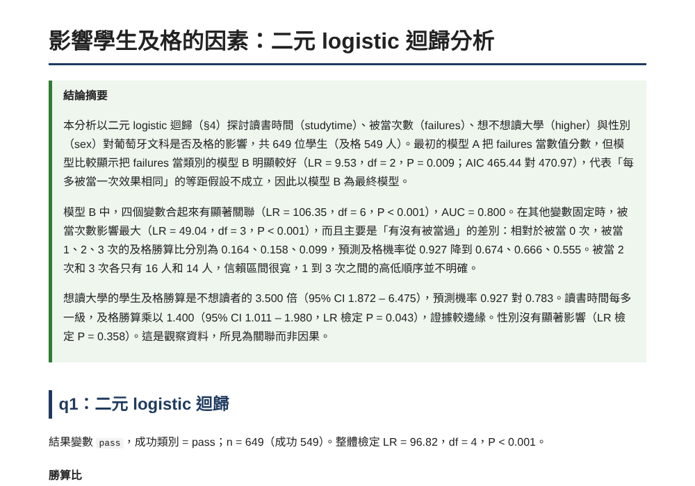

**註釋課本例題核對**

用 Skill 的程式跑課本例題，結果和課本一致：馬蹄蟹的寬度係數 0.497、概似比 31.31；鱷魚「無脊椎 vs 其他」的體長係數 -2.465、概似比 16.80。

# 6 Skill 是怎麼做出來的？

## 6.1 製作流程

[output not shown]

- **範圍**：只處理 Part 2 的三個模型；範圍外（配對資料、計數、連續結果）寫明要怎麼回應，不硬套
- **SKILL.md**：規則寫成「不要做什麼」比較有效，例如「未經同意不配適」，否則 Claude 很容易一次把所有事做完
- **判斷例子不用實測題目**：`decision-tree.md` 的例子全用課本資料，避免先把答案寫進 Skill
- **分工**：判斷「有沒有問題」交給程式（警告代碼），「怎麼解釋」交給 Claude

## 6.2 實測後的改進

做好 Skill 不等於能用。每次實測都會發現問題，修改後再測一次：

| 實測發現的問題 | 原因 | 改進 |
| --- | --- | --- |
| 完全分離的資料讓程式當掉 | 勝算比 $e^{\beta}$ 數值溢位 | 改用安全的指數函式，並發出 `SEPARATION` 警告 |
| Skill 從長條圖「估讀」各組比例 | `plot` 只輸出圖檔，Claude 手上沒有數字 | `plot` 同時印出實際比例；`SKILL.md` 規定只能引用印出的數字 |
| 一步一問，回覆次數太多 | 規則要求每一步都停下來 | 改成**一則確認清單**，附預設值，回「照預設」即可 |
| 懷疑 failures 的等距假設不成立，卻沒辦法檢查 | 沒有比較模型的工具 | 新增 `compare` 指令（概似比檢定、AIC） |
| 分析結果散在對話裡，不方便交給別人 | 沒有整理輸出的工具 | 新增 `report` 指令，產生 HTML 報告 |
| 同一個選項給兩次（`--ref higher=no --ref sex=F`）只保留最後一個 | 程式讀取選項的方式 | 重複的選項全部合併；用同一個指令重跑，結果不變 |
| 練習時重跑選校原因，基準類別變成 course（正式實測是 other），勝算比和報告頁對不上 | 參考組、基準類別由 Claude 自己挑，每次可能不同 | 程式固定預設（參考組 = 第一類；成功類別 = 1／yes／pass；基準類別 = other，沒有就用最後一類），`describe` 印出預設，`SKILL.md` 規定照抄；每個人的結果都相同 |

完整的製作過程（每個檔案怎麼寫、怎麼測試）見 `make-skill-tutorial.html`。

# 7 Skill 應用示範：真實資料實測

**提示情境**

649 位葡萄牙高中生的資料（和 Part 1 同一份）。用三個問題測試 Skill：結果兩類、結果有序、結果名目，各需要不同的模型。

**第一次實測**：在 Claude App 上傳 Skill 後，開一個**新的對話**（看不到我們的判斷和驗證結果），上傳資料檔，像一般使用者一樣提問，例如：

> 用 categorical-modeling skill 分析 student_por.csv：讀書時間、被當次數、想不想讀大學、性別，哪些會影響是否及格？

Skill 不會直接計算，**會先描述資料、跟你確認**：

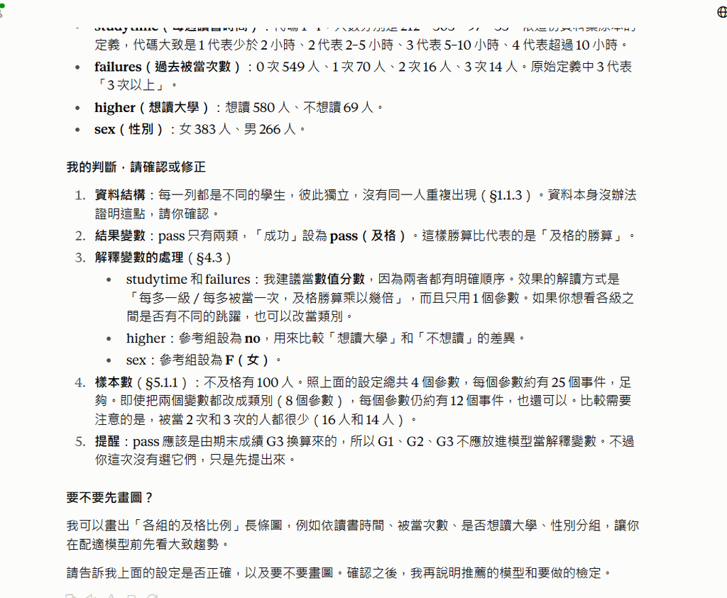

Skill 的確認問題

## 7.1 哪些因素會影響是否及格？

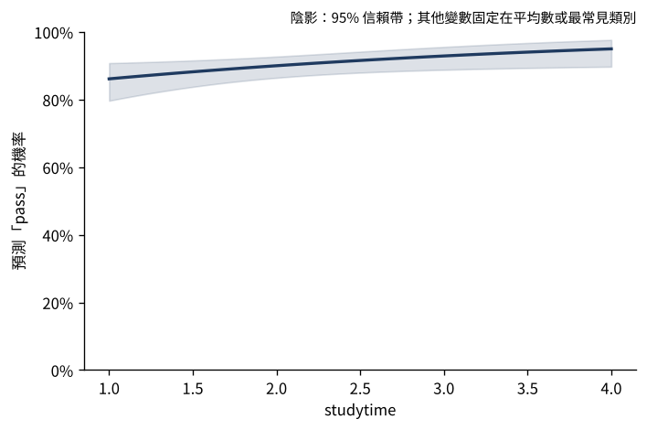

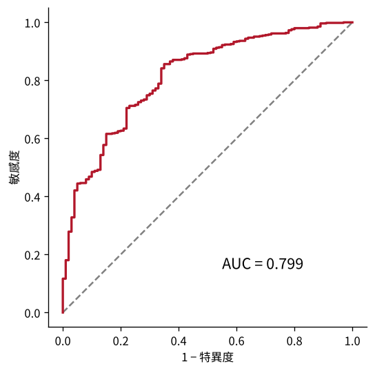

- Skill 選的模型：**二元 logistic 迴歸**（成功類別 = pass）
- studytime（每增加 1）：勝算比 1.45（95% CI 1.05 – 2.05）；概似比檢定 LR = 5.12，P = 0.024
- failures（每增加 1）：勝算比 0.36（95% CI 0.25 – 0.50）；概似比檢定 LR = 39.51，P < 0.001
- higher = yes（相對於 no）：勝算比 3.77（95% CI 2.04 – 6.88）；概似比檢定 LR = 17.24，P < 0.001
- sex = M（相對於 F）：勝算比 0.85（95% CI 0.52 – 1.39）；概似比檢定 LR = 0.43，P = 0.510
- 預測能力：AUC = 0.799

這裡的 failures 是**當數值**算的，代表「平均每多被當一次」的效果。後面的追問會用模型比較檢查這個假設，並改用類別重新配適。

## 7.2 男生和女生的週末飲酒量不同嗎？

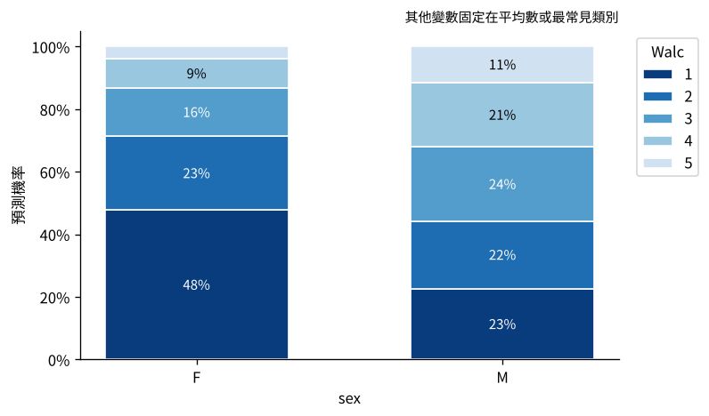

- Skill 選的模型：**累積 logit（比例勝算）**（順序 1 < 2 < 3 < 4 < 5）
- sex = M（相對於 F）：落在較高飲酒量類別的勝算比 3.13（95% CI 2.33 – 4.20）；LR = 59.36，P < 0.001
- 比例勝算假設檢定：LR = 17.21，df = 3，P < 0.001
- ⚠️ Skill 的提醒：比例勝算假設的檢定 P < 0.001：各切點的效果可能不同（例如某組只是分布較分散，而不是整體往上移），單一勝算比可能過度簡化，應分開描述（§6.3.2）。

## 7.3 居住地和學校，跟選校原因有關嗎？

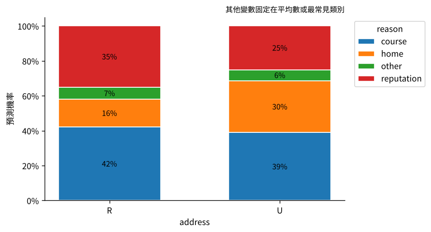

- Skill 選的模型：**baseline-category logit**（基準類別 = other）
- 整體檢定：LR = 64.63，df = 6，P < 0.001
- address 的概似比檢定：LR = 11.83，df = 3，P = 0.008
- school 的概似比檢定：LR = 44.11，df = 3，P < 0.001

## 7.4 追問：被當次數要當數值還是類別？

第一次實測時，Skill 在第 1 題就提醒：被當次數（failures）的效果集中在「0 次 → 1 次」，當數值分數時的等距假設**可能不成立**。但當時 Skill 沒有工具可以檢查。

加入 `compare` 指令後，我在**另一個新對話**重新實測第 1 題（設定和第一次相同），再追問：

> 好，比較 failures 當數值和當類別。

| 模型 | 參數個數 | 對數概似 | AIC |
| --- | --- | --- | --- |
| 模型 A：failures 當數值 | 5 | -230.48 | 470.97 |
| 模型 B：failures 當類別 | 7 | -225.72 | 465.44 |

- 概似比檢定：$LR = 9.53$，$df = 2$，$P = 0.009$
- AIC 較小的是模型 B
- Skill 的結論：P = 0.009，小於 0.05：較複雜的模型 B 明顯比較好，多出來的參數有必要（§5.2）。

**註釋我們的判斷 vs 資料的檢定結果**

- **實測前我們的判斷**：當數值。理由：當作數值比較好，因為它並不是一個 0 或 1 的答案。
- **Skill 用資料檢定的結果**：當類別比較好（$P = 0.009$）
- 兩者**不一致**：等距假設看起來合理，但資料顯示「被當過一次」和「沒被當過」的落差，遠大於之後每多被當一次的差別。這正是需要用檢定確認、不能只憑直覺的地方。

## 7.5 用比較好的模型重新配適

比較只告訴我們哪個模型較好，第 1 題原本的勝算比仍來自 failures 當數值的模型。所以我再請 Skill 用較好的模型重新配適：

> 用 failures 當類別重新配適第 1 題，其他設定不變（成功類別 pass，studytime 當數值，higher 參考組 no，sex 參考組 F）。

| 被當次數 | 勝算比 | 95% CI | 預測及格機率 |
| --- | --- | --- | --- |
| 0 次（參考組） | 1 | — | 0.927 |
| 1 次 | 0.164 | 0.091 – 0.295 | 0.674 |
| 2 次 | 0.158 | 0.052 – 0.484 | 0.666 |
| 3 次 | 0.099 | 0.028 – 0.319 | 0.555 |

- failures 的概似比檢定：$LR = 49.04$，$df = 3$，$P < 0.001$；AUC = 0.800（數值模型是 0.799）
- 預測機率的條件：讀書時間固定在平均數，想讀大學 = yes、性別 = F
- higher = yes（相對於 no）：勝算比 3.50（95% CI 1.87 – 6.48）；$P < 0.001$
- studytime（每增加 1）：勝算比 1.40（95% CI 1.01 – 1.98）；$P = 0.043$
- sex = M（相對於 F）：勝算比 0.79（95% CI 0.48 – 1.30）；$P = 0.358$

**提示重新配適後看到什麼？**

- **效果集中在「有沒有被當過」**：被當 1 次，及格勝算就降到約六分之一，預測機率從 0.927 降到 0.674；被當 2 次、3 次和 1 次差不多
- **數值模型的問題**：它假設每多被當一次，勝算都乘以 0.358，會**低估第一次被當的衝擊**，又**高估之後每多一次的影響**
- 被當 2 次、3 次的學生很少（16 人、14 人），信賴區間很寬，不能斷言 1、2、3 次之間的高低順序
- 其他變數的結論不變：想讀大學、讀書時間和及格有關，性別沒有

最後回覆「更新報告」，Skill 把三次分析（數值模型、模型比較、類別模型）整理成一份 HTML 報告，並在摘要中說明**以類別模型為最終模型**；摘要中提到的每個數字，都能在程式的輸出裡找到。

**註釋實際畫面：重新配適的結果與報告（點開查看）**

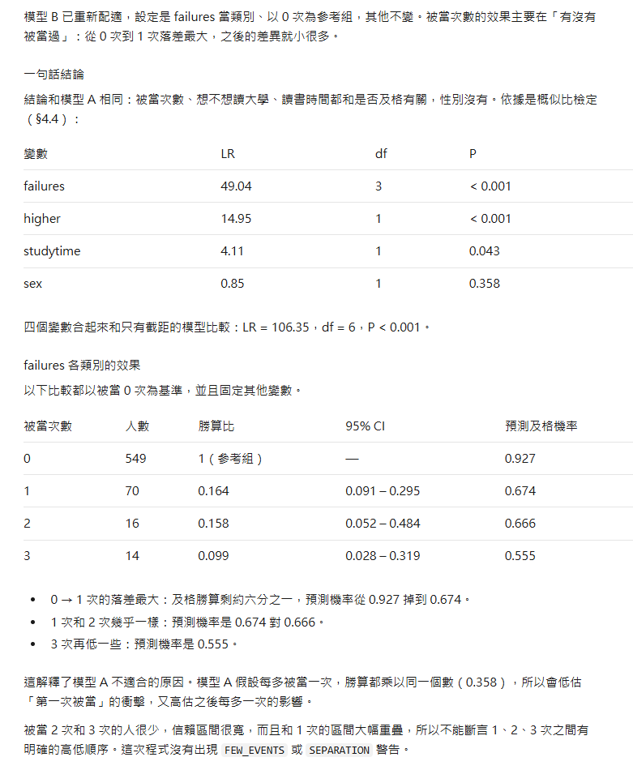

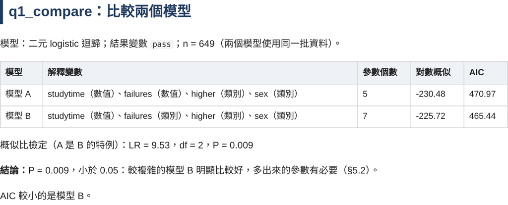

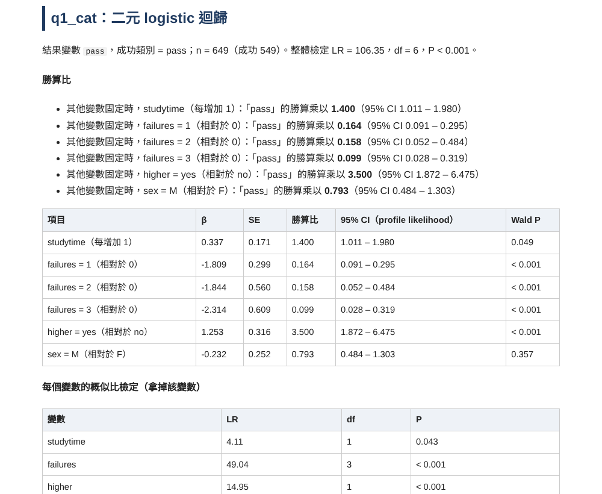

**重要我們怎麼確認 Skill 是對的？**

- **選的模型**：和我們依課本做的判斷，3 題中有 **3 題一樣**
- **算出的數字（第一次實測）**：用另一套獨立的 R 程式重算，21 項中有 **21 項一致**
- **模型比較（第二次實測）**：6 項中有 **6 項一致**；第二次實測第 1 題的 9 個數字也有 9 個一致
- **重新配適（failures 當類別）**：16 項中有 **16 項一致**

**提示實測結論**

- **模型判斷正確**：三題分別選了二元 logistic、累積 logit、baseline-category logit，和我們依課本做的判斷完全一致；每題都先確認資料是否獨立、成功類別、數字代碼當數值或類別、類別順序、基準類別，才推薦模型
- **數字正確**：Skill 用 Python（statsmodels）計算，和我們用 R 獨立重算的結果全部一致（第一次 21 項、第二次模型比較 6 項、重新配適 16 項）
- **解釋到位**：主動提醒 pass 由期末成績換算，G1–G3 不能當解釋變數；第 2 題比例勝算假設不成立時，說明單一勝算比只代表平均效果，沒有把結果壓成兩類
- **比人為判斷多走一步**：我們原本認為被當次數當數值比較好；Skill 先提醒等距假設可能不成立，再用模型比較證實當類別明顯較好；改用類別模型後看出效果集中在「有沒有被當過」
- **實測帶來的改進**：看圖估讀數字、回覆次數太多、沒辦法檢查等距假設、重複選項被忽略，都是實測時發現、修改後再測一次確認的

**註釋核對明細（點開查看）**

**讀書時間（studytime）、被當次數（failures）、想不想讀大學（higher）、性別（sex），哪些會影響是否及格（pass）？**

判斷比對（我們 vs Skill）

| 項目 | 人為判斷 | Skill | 一致 |
| --- | --- | --- | --- |
| 資料結構 | independent | （見對話紀錄） |  |
| 結果變數型態（pass） | binary | （見對話紀錄） |  |
| 解釋變數型態 | ordinal, count, binary, binary | （見對話紀錄） |  |
| 方法 | logistic | logistic | ✅ |
| 設定 | 成功類別 = pass；studytime 當數值分數（1–4）；failures 當數值分數（0–3）；higher、sex 為類別（參考組 no、F） | 成功類別 = pass；當數值：studytime、failures |  |

數字比對（Skill vs 獨立驗證程式）

| 項目 | Skill | 驗證計算 | 一致 | 說明 |
| --- | --- | --- | --- | --- |
| studytime 係數 | 0.3716 | 0.3716 | ✅ |  |
| failures 係數 | -1.0282 | -1.0282 | ✅ |  |
| higher = yes 係數 | 1.3260 | 1.3260 | ✅ |  |
| sex = M 係數 | -0.1643 | -0.1643 | ✅ |  |
| LR 檢定：studytime | 5.1245 | 5.1245 | ✅ |  |
| LR 檢定：failures | 39.5124 | 39.5124 | ✅ |  |
| LR 檢定：higher | 17.2428 | 17.2428 | ✅ |  |
| LR 檢定：sex | 0.4336 | 0.4336 | ✅ |  |
| ROC 曲線下面積 | 0.7990 | 0.7990 | ✅ |  |

**男生和女生的週末飲酒量（Walc，1 很少 – 5 很多）不同嗎？**

判斷比對（我們 vs Skill）

| 項目 | 人為判斷 | Skill | 一致 |
| --- | --- | --- | --- |
| 資料結構 | independent | （見對話紀錄） |  |
| 結果變數型態（Walc） | ordinal | （見對話紀錄） |  |
| 解釋變數型態 | binary | （見對話紀錄） |  |
| 方法 | cumulative_logit | cumulative_logit | ✅ |
| 設定 | Walc 順序 1 < 2 < 3 < 4 < 5；sex 參考組 = F | 沒有變數當數值；Walc 順序：1 < 2 < 3 < 4 < 5 |  |

數字比對（Skill vs 獨立驗證程式）

| 項目 | Skill | 驗證計算 | 一致 | 說明 |
| --- | --- | --- | --- | --- |
| sex = M：落在較高類別的勝算比 | 3.1270 | 3.1271 | ✅ |  |
| LR 檢定：sex | 59.3575 | 59.3575 | ✅ |  |
| 比例勝算假設檢定 LR | 17.2140 | 17.2140 | ✅ | 非比例勝算模型：Skill 自行以最大概似法配適，驗證程式用 R 的 ordinal 套件 |

**居住地（address，都市／鄉村）和就讀學校（school），跟選校原因（reason）有關嗎？**

判斷比對（我們 vs Skill）

| 項目 | 人為判斷 | Skill | 一致 |
| --- | --- | --- | --- |
| 資料結構 | independent | （見對話紀錄） |  |
| 結果變數型態（reason） | nominal | （見對話紀錄） |  |
| 解釋變數型態 | binary, binary | （見對話紀錄） |  |
| 方法 | baseline_logit | baseline_logit | ✅ |
| 設定 | 基準類別 = other；address 參考組 = R；school 參考組 = GP | 沒有變數當數值；基準類別 = other |  |

數字比對（Skill vs 獨立驗證程式）

| 項目 | Skill | 驗證計算 | 一致 | 說明 |
| --- | --- | --- | --- | --- |
| 整體模型 LR | 64.6261 | 64.6261 | ✅ |  |
| LR 檢定：address | 11.8318 | 11.8318 | ✅ |  |
| LR 檢定：school | 44.1146 | 44.1146 | ✅ |  |
| course vs other：addressU 係數 | 0.0142 | 0.0143 | ✅ |  |
| course vs other：schoolMS 係數 | -0.8532 | -0.8532 | ✅ |  |
| home vs other：addressU 係數 | 0.7196 | 0.7196 | ✅ |  |
| home vs other：schoolMS 係數 | -1.5073 | -1.5073 | ✅ |  |
| reputation vs other：addressU 係數 | -0.2432 | -0.2432 | ✅ |  |
| reputation vs other：schoolMS 係數 | -1.9668 | -1.9668 | ✅ |  |

**第二次實測：第 1 題的追問：failures（被當次數 0–3）當數值分數好，還是當類別好？**

| 項目 | Skill | 驗證計算 | 一致 | 說明 |
| --- | --- | --- | --- | --- |
| 對數概似：failures 當數值 | -230.4832 | -230.4832 | ✅ |  |
| 對數概似：failures 當類別 | -225.7201 | -225.7201 | ✅ |  |
| AIC：failures 當數值 | 470.9664 | 470.9664 | ✅ |  |
| AIC：failures 當類別 | 465.4403 | 465.4403 | ✅ |  |
| 概似比檢定 LR | 9.5261 | 9.5261 | ✅ |  |
| 概似比檢定 P 值 | 0.0085 | 0.0085 | ✅ |  |

**第二次實測：第 1 題的數字**

| 項目 | Skill | 驗證計算 | 一致 | 說明 |
| --- | --- | --- | --- | --- |
| studytime 係數 | 0.3716 | 0.3716 | ✅ |  |
| failures 係數 | -1.0282 | -1.0282 | ✅ |  |
| higher = yes 係數 | 1.3260 | 1.3260 | ✅ |  |
| sex = M 係數 | -0.1643 | -0.1643 | ✅ |  |
| LR 檢定：studytime | 5.1245 | 5.1245 | ✅ |  |
| LR 檢定：failures | 39.5124 | 39.5124 | ✅ |  |
| LR 檢定：higher | 17.2428 | 17.2428 | ✅ |  |
| LR 檢定：sex | 0.4336 | 0.4336 | ✅ |  |
| ROC 曲線下面積 | 0.7990 | 0.7990 | ✅ |  |

**第二次實測：failures 當類別重新配適**

| 項目 | Skill | 驗證計算 | 一致 | 說明 |
| --- | --- | --- | --- | --- |
| 勝算比：failures = 1 vs 0 | 0.1639 | 0.1639 | ✅ |  |
| 勝算比：failures = 2 vs 0 | 0.1581 | 0.1581 | ✅ |  |
| 勝算比：failures = 3 vs 0 | 0.0988 | 0.0988 | ✅ |  |
| 勝算比：studytime | 1.4001 | 1.4001 | ✅ |  |
| 勝算比：higher = yes | 3.4999 | 3.4999 | ✅ |  |
| 勝算比：sex = M | 0.7926 | 0.7926 | ✅ |  |
| LR 檢定：failures（df = 3） | 49.0385 | 49.0385 | ✅ |  |
| LR 檢定：studytime | 4.1119 | 4.1119 | ✅ |  |
| LR 檢定：higher | 14.9539 | 14.9539 | ✅ |  |
| LR 檢定：sex | 0.8465 | 0.8465 | ✅ |  |
| 整體模型 LR | 106.3453 | 106.3453 | ✅ |  |
| 預測及格機率：被當 0 次 | 0.9266 | 0.9266 | ✅ |  |
| 預測及格機率：被當 1 次 | 0.6741 | 0.6741 | ✅ |  |
| 預測及格機率：被當 2 次 | 0.6662 | 0.6662 | ✅ |  |
| 預測及格機率：被當 3 次 | 0.5551 | 0.5551 | ✅ |  |
| ROC 曲線下面積 | 0.8000 | 0.8000 | ✅ |  |

- 實測在新的 Claude 對話中進行，只上傳 Skill 和資料，看不到我們的判斷和驗證結果
- 驗證程式用課本示範的 R 指令（`glm`、`anova`、`MASS`、`ordinal`、`nnet`），Skill 用 Python 的 statsmodels：兩邊是不同語言、不同套件，各自獨立計算
- 資料結構與變數型態是 Skill 在對話中和使用者確認的，詳見對話紀錄（`demo/part2/skill/transcript.md`、`demo/part2/skill/round2/transcript.md`）

# 8 重點整理

| 重點 | 內容 |
| --- | --- |
| 方法 | 結果兩類用 logistic 迴歸；三類以上依有沒有順序，選 baseline-category logit 或累積 logit |
| Skill 能做什麼 | 選模型、配適、白話解釋，還能比較兩個模型、產生 HTML 報告 |
| Skill 的分工 | Claude 判斷、確認、解釋；程式（Python）負責所有計算 |
| Skill 的結構 | `SKILL.md`（規則與流程）＋ `references/`（速查、課本細節、決策樹）＋ `scripts/run_model.py`（計算、比較、報告） |
| Skill 的特色 | 一則確認清單、未經同意不計算；每個方法都有課本依據；主動提醒分離、樣本數、比例勝算、等距假設等問題 |
| 怎麼確認 Skill 是對的 | 和我們依課本做的判斷比對，數字用另一套獨立的 R 程式重算；實測發現的問題修改後再測一次 |

**提示下一步**

以上都假設**每筆資料彼此獨立**。同一個學生考兩次、同一班的學生互相影響時，要用 Part 3 的方法。

# 參考文獻

Agresti, A. (2019). *An Introduction to Categorical Data Analysis* (3rd ed.). John Wiley & Sons.

Cortez, P., & Silva, A. (2008). Using data mining to predict secondary school student performance. In *Proceedings of 5th Future Business Technology Conference* (pp. 5–12). UCI Machine Learning Repository. https://doi.org/10.24432/C5TG7T